# Least-squares fitting

Dr. Brinda

September 3, 2019

## Task 1 (warm-up)

> Suppose $(x_1, x_2, x_3) = (3, 4, 3)$ and $(y_1, y_2, y_3) = (8.2, 4.6, 4.4)$. Without using the least-squares line formula, identify the least-squares line, and explain your answer. Sketch a scatterplot, and draw the least-squares line in red.

Briefly explain your answer here. we can use minimize the sum of squared error(residuals) to solve the least-quares line.
$$(y - \hat{y})^2= \sum_i(y_i - a - bx_i)^2$$
we can use derivative with respect to a and b make the derivative equal to 0 to get the local optimization, which is
$$-2\sum_i(y_i -a -bx_i) = 0 \\
a = \bar{y}- b\bar{x}$$
Then, we can calculate the derivative with respect to b
$$\begin{align*}
-2\sum_i(y_i -\bar{y}-(x_i - \bar{x})b)& = 0\\
\hat b&=\frac{\sum_i(y_i-\bar{y})(x_i - \bar{x})}{\sum_i(x_i -\bar{x})^2}\\
\hat a&= \bar{y}-\frac{\sum_i(y_i-\bar{y})(x_i - \bar{x})}{\sum_i(x_i -\bar{x})^2}\bar{x}
\end{align*}$$

```r
x <- c(3,4,3)
y <- c(8.2, 4.6, 4.4)

b.hat <- sum((y -mean(y))*(x-mean(x)))/ sum((x - mean(x))^2);b.hat
```

```
## [1] -1.7
```

```r
b.hat <- as.vector(b.hat)
a.hat <- mean(y) - b.hat*mean(x);a.hat
```

```
## [1] 11.4
```

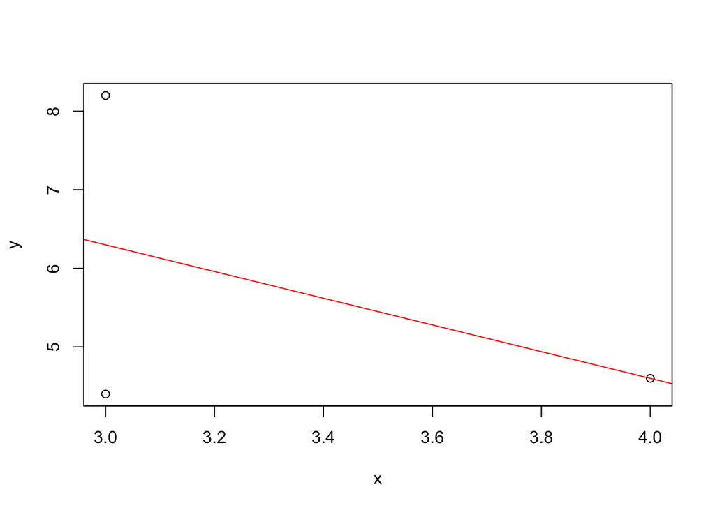

```r
plot(x,y)
abline(a.hat, b.hat, col="red")
```

## AirPassenger data least-squares line (review)

From last time:

```r
y <- AirPassengers
x <- seq(1949, 1960+11/12, by=1/12)

plot(x, y, type="l", xlab="time", ylab="thousands of international airline passengers")

# least-squares slope
b.hat <- (t(x - mean(x)) %*% y)/sum((x - mean(x))^2)
b.hat
```

```
##          [,1]
## [1,] 31.88621
```

```r
b.hat <- as.vector(b.hat)
b.hat
```

```
## [1] 31.88621
```

```r
# least-squares intercept
a.hat <- mean(y) - b.hat*mean(x)
a.hat
```

```
## [1] -62055.91
```

```r
# using the design matrix formula
X <- cbind(1, x)
solve(t(X) %*% X) %*% t(X) %*% y
```

```
##           [,1]
##   -62055.90728
## x     31.88621
```

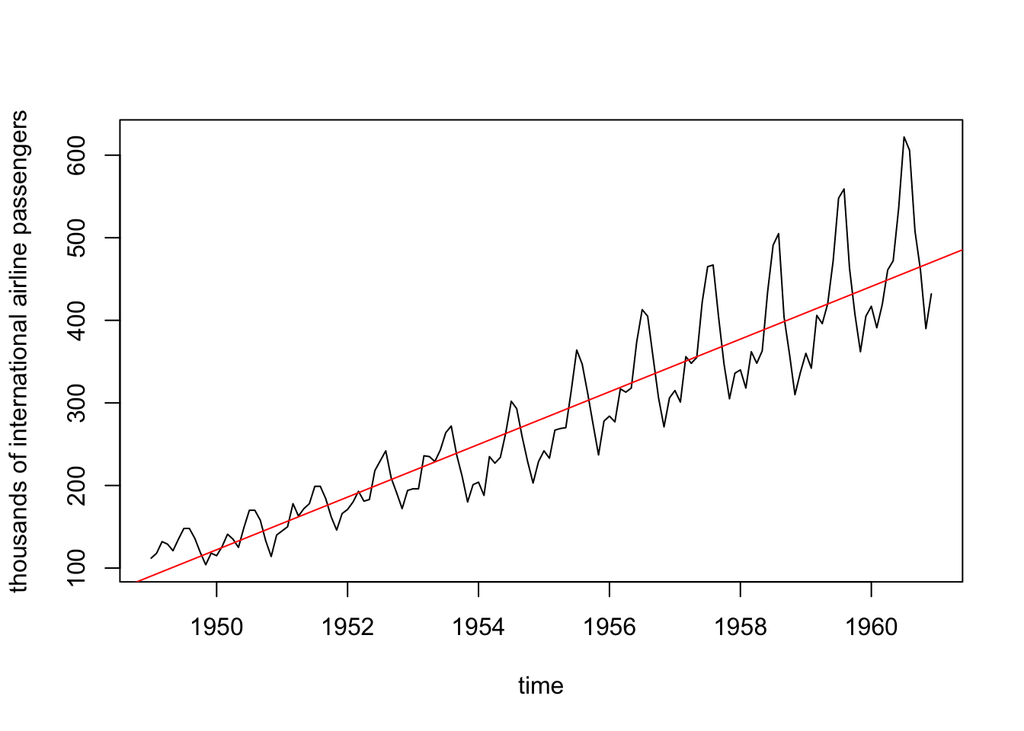

```r
# A line doesn't fully capture the pattern exhibited this data,
# but here's the least-squares line anyway.
abline(a.hat, b.hat, col="red")
```

```r
# the least-squares predictions are
y.hat <- a.hat + b.hat*x

# or using the design matrix formula
# X %*% solve(t(X) %*% X) %*% t(X) %*% y
```

```r
# Verifying the ANOVA decomposition

# variance of prediction vector
var(y.hat)
```

```
## [1] 12285.49
```

```r
# equal to variance of regression vector
var(y.hat - mean(y))
```

```
## [1] 12285.49
```

```r
# variance of residuals
var(y - y.hat)
```

```
## [1] 2106.427
```

```r
# sum of the two variances
var(y.hat) + var(y - y.hat)
```

```
## [1] 14391.92
```

```r
# variance of response vector
var(y)
```

```
## [1] 14391.92
```

## AirPassenger data least-squares quadratic

Next, let’s find the least-squares quadratic, that is, the function of the form $a + b*x + c*x^2$ that minimizes the sum of squared residuals. The trick is to treat $\mathbf{x}^2$ as another variable and add a corresponding column to the design matrix.

```r
X <- cbind(1, x, x^2)
```

If you try the following code, you get an error. Your computer has numerical difficulty because the explanatory vectors are pointing too close to the same direction.

```r
ls.coeffs <- solve(t(X) %*% X) %*% t(X) %*% y
```

Recall that we can replace $\mathbf{x}$ by $\mathbf{x} - \mathbf{\bar{x}}$ which is orthogonal to the $\mathbf{1}$ vector without changing their span.

```r
X <- cbind(1, x - mean(x), (x - mean(x))^2)
ls.coeffs <- solve(t(X) %*% X) %*% t(X) %*% y
```

Let’s draw the least-squares quadratic curve onto our plot

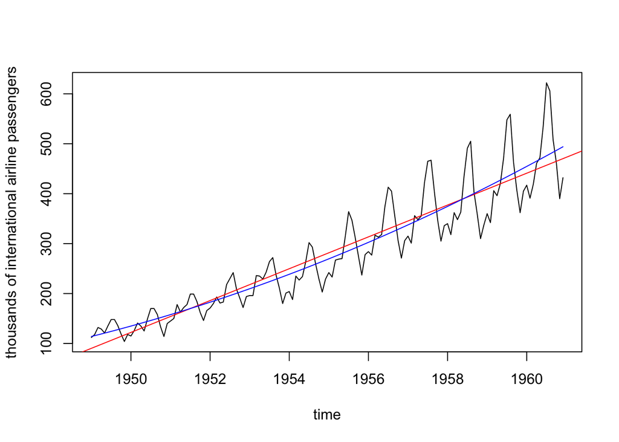

```r
plot(x, y, type="l", xlab="time", ylab="thousands of international airline passengers")
abline(a.hat, b.hat, col="red")
y.hat2 <- ls.coeffs[1] + ls.coeffs[2]*(x - mean(x)) + ls.coeffs[3]*(x - mean(x))^2
lines(x, y.hat2, col="blue")
```

When the centered version of $\mathbf{x}$ is used, the least-squares coefficients are:

```r
round(ls.coeffs, 2)
```

```
##        [,1]
## [1,] 268.19
## [2,]  31.89
## [3,]   1.01
```

## Task 2 (simple)

> Rearrange the expression into the form $a + b x + c x^2$ in order to identify the least-squares intercept and least-squares coefficients of $x$ and $x^2$. You don’t need to show your work, but when you’ve found the least-squares coefficients, type them into the equation below, replacing $\hat{a}$, $\hat{b}$, and $\hat{c}$.

$$y = 3794881 -3913.926 x + 1.009 x^2$$

$$\begin{align*}
y&= a + b(x- \bar{x}) + c(x- \bar{x})^2\\
&= [a-b\bar{x}+c{\bar{x}}^2]+(b-2c\bar{x})+cx^2\\
\end{align*}$$

## Task 3 (more challenging)

> Identify a vector whose variance is equal to: answer should be$y.hat -y.hat2$

```r
var(y - y.hat) - var(y - y.hat2)
```

```
## [1] 118.1169
```

Due to the character of orthogonal projection, we have $y_2$ is the orthogonal projection to $span \left\{1,x,x^2 \right\}$ and $y_1$ is the orthogonal projection to $span \left\{1,x \right\}$,thus, $y_2$, $y_1$ and their linear combination all in $span \left\{1,x,x^2 \right\}$ ,so $y-y_2$ should orthogonal to $span \left\{1,x,x^2 \right\}$, $y_1-y_2 \in span \left\{1,x,x^2 \right\}$ Then,we have that the $y_1-y_2$ and $y-y_2$ are two sides of a right triangular. According to the Pythagorean theorem
$$\left\| y -y_1\right\|^2 = \left\| y_2 -y_1\right\|^2 + \left\| y -y_2\right\|^2$$
divided by $n$ is the empirical variance

> In the R code block below, use the “var” function to check your answer.

```r
var(y.hat-y.hat2)
```

```
## [1] 118.1169
```